# The SEIR Model, $R_0$, and the Next-Generation Matrix: Walkthrough and Homework 2

MATH 4320 — Mathematical Epidemiology and Network Dynamics, Week 3

October 11, 2026

## How to use this document

This document has two parts.

- **Part A (Sections 1–6)** walks through the Week 3 theory with working code, in the same order as the lecture. Every chunk runs as written. Read the text, run the chunk, and check that the output says what the text claims.
- **Part B (Homework 2)** asks seven questions; the last one is optional. Each has a **math** part, which you answer in this document using LaTeX between dollar signs (as the theory sections below do), and a **code** part, which you answer by extending the code from Part A in the empty chunk provided.

To submit: put your name in the `author:` field at the top, knit to HTML, and push both the `.Rmd` and the `.html` to your course repository.

Two conventions are used throughout, matching the notes. Everything is in **proportions** ($S+E+I+R=1$), and time is measured in **days**, so every rate is “per day.”

# Part A: Walkthrough

## 1. The model

Week 1 assumed that an infected host is infectious immediately. The SEIR model relaxes that: a newly infected host first enters an **exposed** class $E$ (infected, not yet infectious) and moves on to $I$ at rate $\sigma$, so that $1/\sigma$ is the mean latent period. With birth and death rate $\mu$:

$$\begin{aligned}
S' &= \mu - \beta I S - \mu S, \\
E' &= \beta I S - (\sigma+\mu)E, \\
I' &= \sigma E - (\gamma+\mu)I, \\
R' &= \gamma I - \mu R.
\end{aligned}$$

In code, the model is a function that takes the current state and returns the four derivatives. This is the form `deSolve` expects.

```r
seir <- function(t, y, parms) {
  with(as.list(c(y, parms)), {
    dS <- mu - beta * I * S - mu * S
    dE <- beta * I * S - (sigma + mu) * E
    dI <- sigma * E - (gamma + mu) * I
    dR <- gamma * I - mu * R
    list(c(dS, dE, dI, dR))
  })
}
```

Our running example is a flu-like infection: a latent period of 3 days, an infectious period of 5 days, and a life expectancy of 70 years.

```r
parms <- c(beta  = 0.6,            # transmission coefficient, per day
           sigma = 1 / 3,          # 1 / latent period
           gamma = 1 / 5,          # 1 / infectious period
           mu    = 1 / (70 * 365)) # 1 / life expectancy
```

A small helper runs the solver and returns a data frame. The tight tolerances matter later, when $I$ becomes very small.

```r
run_seir <- function(parms, y0, times) {
  as.data.frame(ode(y = y0, times = times, func = seir, parms = parms,
                    rtol = 1e-8, atol = 1e-12))
}

y0    <- c(S = 1 - 1e-6, E = 0, I = 1e-6, R = 0)   # one infectious host per million
times <- seq(0, 200, by = 0.5)
out   <- run_seir(parms, y0, times)
head(out)
```

```
##   time         S            E            I            R
## 1  0.0 0.9999990 0.000000e+00 1.000000e-06 0.000000e+00
## 2  0.5 0.9999987 2.647879e-07 9.270382e-07 9.592304e-08
## 3  1.0 0.9999984 4.753574e-07 8.983508e-07 1.868740e-07
## 4  1.5 0.9999982 6.505763e-07 9.027325e-07 2.766844e-07
## 5  2.0 0.9999979 8.038603e-07 9.325704e-07 3.682554e-07
## 6  2.5 0.9999976 9.448418e-07 9.827799e-07 4.638610e-07
```

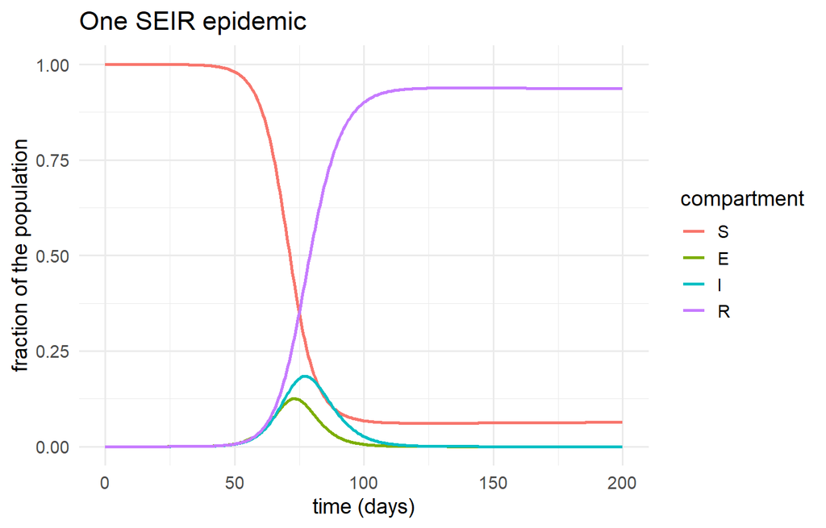

```r
to_long <- function(out, vars = c("S", "E", "I", "R")) {
  data.frame(time        = rep(out$time, length(vars)),
             compartment = factor(rep(vars, each = nrow(out)), levels = vars),
             fraction    = unlist(out[vars], use.names = FALSE))
}

ggplot(to_long(out), aes(time, fraction, colour = compartment)) +
  geom_line(linewidth = 1) +
  labs(x = "time (days)", y = "fraction of the population",
       title = "One SEIR epidemic")
```

The $E$ curve rises first and the $I$ curve follows it: every infectious host was exposed a few days earlier.

## 2. What the latent period changes, and what it does not

The notes derive

$$R_0 = \beta\cdot\frac{\sigma}{\sigma+\mu}\cdot\frac{1}{\gamma+\mu}
= \frac{\beta\sigma}{(\sigma+\mu)(\gamma+\mu)} .$$

The latent period enters only through $\sigma/(\sigma+\mu)$, the probability of surviving latency, which is essentially $1$ when the latent period is days and a lifetime is decades.

```r
R0_formula <- function(parms) {
  with(as.list(parms), beta * sigma / ((sigma + mu) * (gamma + mu)))
}
R0_formula(parms)
```

```
## [1] 2.999061
```

So changing the latent period should leave $R_0$ almost untouched. Here are three latent periods, everything else fixed.

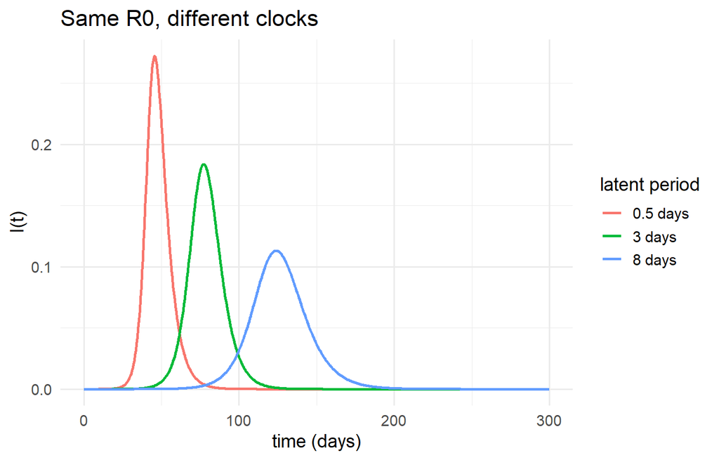

```r
latent_days <- c(0.5, 3, 8)

runs <- lapply(latent_days, function(L) {
  p <- parms
  p["sigma"] <- 1 / L
  d <- run_seir(p, y0, seq(0, 300, by = 0.5))
  d$latent <- paste(L, "days")
  d$R0 <- R0_formula(p)
  d
})
runs <- do.call(rbind, runs)
runs$latent <- factor(runs$latent, levels = paste(latent_days, "days"))

ggplot(runs, aes(time, I, colour = latent)) +
  geom_line(linewidth = 1) +
  labs(x = "time (days)", y = "I(t)", colour = "latent period",
       title = "Same R0, different clocks")
```

```r
do.call(rbind, lapply(split(runs, runs$latent), function(d) {
  data.frame(latent_period = d$latent[1],
             R0            = round(d$R0[1], 4),
             peak_day      = d$time[which.max(d$I)],
             peak_I        = round(max(d$I), 4),
             lowest_S      = round(min(d$S), 3))
}))
```

```
##          latent_period     R0 peak_day peak_I lowest_S
## 0.5 days      0.5 days 2.9994     45.5 0.2722    0.061
## 3 days          3 days 2.9991     77.0 0.1837    0.061
## 8 days          8 days 2.9985    124.0 0.1131    0.062
```

$R_0$ differs by less than one part in a thousand across the three runs, and the lowest value $S$ reaches, a measure of how much of the population the epidemic infects, is close in all three. (The small differences come from births, which keep adding susceptibles while the slower epidemics run. Question 2 of the homework removes births and makes the statement exact.) What changes is *when* the epidemic happens, and how tall its peak is.

### How fast does it grow?

Early in an epidemic $S\approx 1$, and the infected compartments obey the linearization at the disease-free equilibrium. The notes show that, apart from the eigenvalue $\Lambda_1=-\mu$, the eigenvalues $\Lambda$ of $J(P_0)$ are the roots of

$$\Lambda^2+(\sigma+\gamma+2\mu)\,\Lambda+(\sigma+\mu)(\gamma+\mu)(1-R_0)=0
.$$

When $R_0>1$ its roots have opposite signs. The positive root, call it $r$, is the **early exponential growth rate**: $I(t)$ grows like $e^{rt}$.

```r
growth_rate <- function(parms) {
  with(as.list(parms), {
    b  <- sigma + gamma + 2 * mu
    c0 <- (sigma + mu) * (gamma + mu) * (1 - R0_formula(parms))
    (-b + sqrt(b^2 - 4 * c0)) / 2
  })
}
r_predicted <- growth_rate(parms)
r_predicted
```

```
## [1] 0.1854495
```

That is a prediction from a matrix. We can test it against the simulation by fitting a straight line to $\log I(t)$ over the early part of the epidemic.

```r
t_peak <- out$time[which.max(out$I)]
early  <- subset(out, time < t_peak & I > 1e-5 & I < 1e-3)
fit    <- lm(log(I) ~ time, data = early)

c(predicted = r_predicted, fitted = unname(coef(fit)["time"]))
```

```
## predicted    fitted
## 0.1854495 0.1853531
```

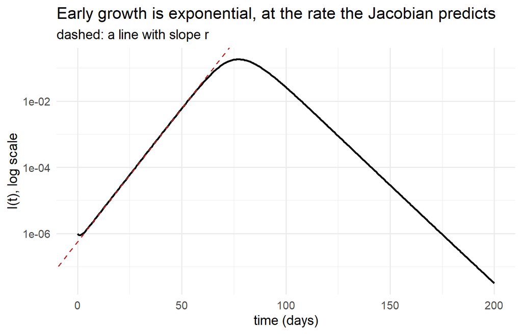

```r
ggplot(out, aes(time, I)) +
  geom_line(linewidth = 1) +
  geom_abline(intercept = coef(fit)[1] / log(10), slope = r_predicted / log(10),
              linetype = "dashed", colour = "firebrick") +
  scale_y_log10() +
  labs(x = "time (days)", y = "I(t), log scale",
       title = "Early growth is exponential, at the rate the Jacobian predicts",
       subtitle = "dashed: a line with slope r")
```

For comparison, the SIR model with the same $\beta$ and $\gamma$ grows at rate $\beta-(\gamma+\mu)$:

```r
c(SEIR = r_predicted,
  SIR  = unname(parms["beta"] - (parms["gamma"] + parms["mu"])))
```

```
##      SEIR       SIR
## 0.1854495 0.3999609
```

The two models have almost the same $R_0$, but the SEIR epidemic grows at less than half the speed. **$R_0$ counts infections per generation; it says nothing about how long a generation takes.** Question 6 of the homework turns this around.

## 3. Equilibria

Setting the right-hand sides to zero gives the disease-free equilibrium $P_0=(1,0,0)$ and, when $R_0>1$, the endemic equilibrium

$$S^*=\frac{1}{R_0},\qquad I^*=\frac{\mu}{\beta}(R_0-1),\qquad
E^*=\frac{\gamma+\mu}{\sigma}\,I^* .$$

```r
endemic_eq <- function(parms) {
  with(as.list(parms), {
    R0     <- R0_formula(parms)
    S_star <- 1 / R0
    I_star <- mu / beta * (R0 - 1)
    E_star <- (gamma + mu) / sigma * I_star
    c(S = S_star, E = E_star, I = I_star, R = 1 - S_star - E_star - I_star)
  })
}
P_star <- endemic_eq(parms)
P_star
```

```
##            S            E            I            R
## 3.334377e-01 7.825644e-05 1.304019e-04 6.663536e-01
```

A formula for an equilibrium is easy to check: plug it into the model and the derivatives should all be zero.

```r
seir(0, P_star, parms)[[1]]
```

```
## [1] -1.694066e-21  3.388132e-21 -3.388132e-21  3.388132e-21
```

Notice how small $I^*$ is. At the endemic equilibrium about a third of the population is susceptible, but only about one person in ten thousand is infectious at any moment.

## 4. The next-generation matrix

The general recipe: take the infected compartments only, $x=(E,I)$, and write $x'=\mathcal{F}-\mathcal{V}$, where $\mathcal{F}$ holds the **new infections** and $\mathcal{V}$ holds every other transfer. For SEIR,

$$\mathcal{F}=\begin{pmatrix}\beta I S\\ 0\end{pmatrix},\qquad
\mathcal{V}=\begin{pmatrix}(\sigma+\mu)E\\ (\gamma+\mu)I-\sigma
E\end{pmatrix}.$$

Differentiating with respect to $(E,I)$ at the disease-free equilibrium $(S,E,I)=(1,0,0)$ gives

$$F=\begin{pmatrix}0&\beta\\0&0\end{pmatrix},\qquad
V=\begin{pmatrix}\sigma+\mu&0\\-\sigma&\gamma+\mu\end{pmatrix},$$

and then $K=FV^{-1}$ and $R_0=\rho(K)$, the largest eigenvalue of $K$ in absolute value.

```r
ngm <- function(parms) {
  with(as.list(parms), {
    nm   <- list(c("E", "I"), c("E", "I"))
    Fmat <- matrix(c(0, beta,
                     0, 0), nrow = 2, byrow = TRUE, dimnames = nm)
    Vmat <- matrix(c(sigma + mu, 0,
                     -sigma,     gamma + mu), nrow = 2, byrow = TRUE, dimnames = nm)
    Vinv <- solve(Vmat)          # matrix inverse
    K    <- Fmat %*% Vinv        # matrix product
    list(F = Fmat, V = Vmat, Vinv = Vinv, K = K,
         R0 = max(Mod(eigen(K)$values)))
  })
}
res <- ngm(parms)
res$F
```

```
##   E   I
## E 0 0.6
## I 0 0.0
```

```r
res$V
```

```
##            E         I
## E  0.3333725 0.0000000
## I -0.3333333 0.2000391
```

$V^{-1}$ has a meaning of its own. Entry $(i,j)$ is the expected time that a host starting in compartment $j$ (column) spends in compartment $i$ (row).

```r
res$Vinv
```

```
##          E        I
## E 2.999648 0.000000
## I 4.998435 4.999022
```

Read the first column: a host entering $E$ spends about 3 days there and then, on average, about 5 days in $I$. Read the second column: a host placed directly in $I$ spends about 5 days there and never visits $E$.

Multiplying by $F$ turns time spent into new infections produced:

```r
res$K
```

```
##          E        I
## E 2.999061 2.999413
## I 0.000000 0.000000
```

```r
eigen(res$K)$values
```

```
## [1] 2.999061 0.000000
```

```r
c(from_matrix = res$R0, from_formula = R0_formula(parms))
```

```
##  from_matrix from_formula
##     2.999061     2.999061
```

The matrix method and the formula agree. The bottom row of $K$ is zero because every new infection enters $E$; none enters $I$ directly.

## 5. Local stability

The Jacobian of the reduced system, in the order $(S,E,I)$, is

$$J(S,E,I)=\begin{pmatrix}
-\beta I-\mu & 0 & -\beta S\\
\beta I & -(\sigma+\mu) & \beta S\\
0 & \sigma & -(\gamma+\mu)
\end{pmatrix}.$$

```r
jacobian <- function(state, parms) {
  with(as.list(c(state, parms)), {
    matrix(c(-beta * I - mu,  0,              -beta * S,
              beta * I,       -(sigma + mu),   beta * S,
              0,               sigma,         -(gamma + mu)),
           nrow = 3, byrow = TRUE)
  })
}
P_0 <- c(S = 1, E = 0, I = 0)

eigen(jacobian(P_0, parms))$values
```

```
## [1] -7.188611e-01  1.854495e-01 -3.913894e-05
```

```r
eigen(jacobian(P_star, parms))$values
```

```
## [1] -5.334300e-01+0.000000000i -4.951959e-05+0.003127136i
## [3] -4.951959e-05-0.003127136i
```

At $P_0$ one eigenvalue is positive, so $P_0$ is unstable. That positive eigenvalue is exactly the growth rate $r$ from Section 2. At $P^*$ all three real parts are negative, so $P^*$ is asymptotically stable, as the theorem in the notes says it must be when $R_0>1$.

The notes prove the $P^*$ case through the Routh–Hurwitz conditions: $\operatorname{tr}J<0$, $\det J<0$, and $\operatorname{tr}J\cdot a_2-\det J<0$, where $a_2$ is the sum of the three $2\times 2$ principal minors.

```r
J  <- jacobian(P_star, parms)
tr <- sum(diag(J))
a2 <- det(J[c(1, 2), c(1, 2)]) + det(J[c(1, 3), c(1, 3)]) + det(J[c(2, 3), c(2, 3)])
c(trace = tr, a2 = a2, det = det(J), third_condition = tr * a2 - det(J))
```

```
##           trace              a2             det third_condition
##   -5.335290e-01    6.261189e-05   -5.217709e-06   -2.818755e-05
```

One set of parameters is an example, not a proof. But we can at least watch the theorem hold across a whole range of $\beta$, passing through $R_0=1$.

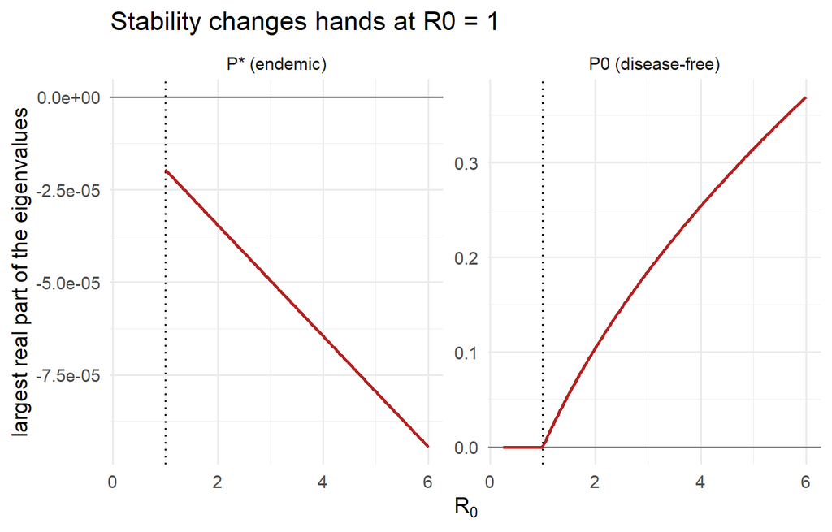

```r
beta_grid <- seq(0.05, 1.2, length.out = 200)

sweep <- do.call(rbind, lapply(beta_grid, function(b) {
  p <- parms
  p["beta"] <- b
  R0 <- R0_formula(p)
  at_P0    <- max(Re(eigen(jacobian(P_0, p))$values))
  at_Pstar <- if (R0 > 1) max(Re(eigen(jacobian(endemic_eq(p), p))$values)) else NA
  data.frame(R0 = R0,
             equilibrium = c("P0 (disease-free)", "P* (endemic)"),
             leading = c(at_P0, at_Pstar))
}))
sweep <- na.omit(sweep)

ggplot(sweep, aes(R0, leading)) +
  geom_hline(yintercept = 0, colour = "grey50") +
  geom_vline(xintercept = 1, linetype = "dotted") +
  geom_line(linewidth = 1, colour = "firebrick") +
  facet_wrap(~ equilibrium, scales = "free_y") +
  labs(x = expression(R[0]), y = "largest real part of the eigenvalues",
       title = "Stability changes hands at R0 = 1")
```

## 6. The slow approach to the endemic equilibrium

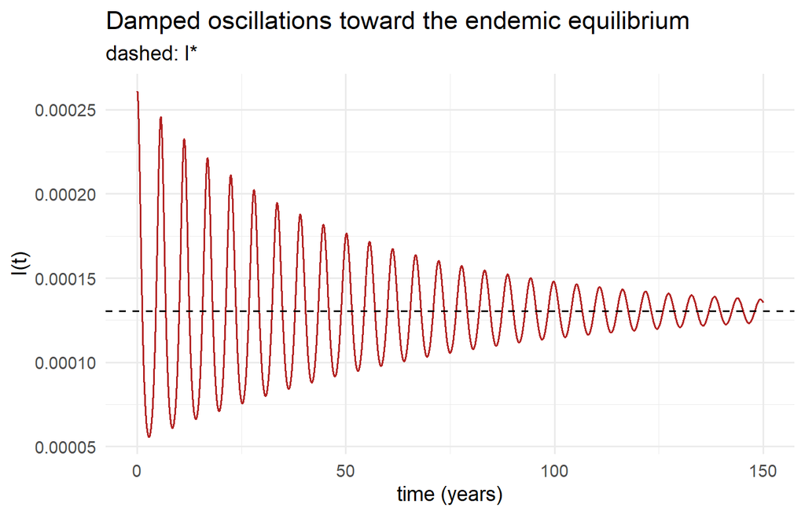

```r
y_near <- c(S = P_star[["S"]], E = 2 * P_star[["E"]], I = 2 * P_star[["I"]])
y_near <- c(y_near, R = 1 - sum(y_near))

long_run <- run_seir(parms, y_near, seq(0, 150 * 365, by = 5))

ggplot(long_run, aes(time / 365, I)) +
  geom_line(colour = "firebrick") +
  geom_hline(yintercept = P_star[["I"]], linetype = "dashed") +
  labs(x = "time (years)", y = "I(t)",
       title = "Damped oscillations toward the endemic equilibrium",
       subtitle = "dashed: I*")
```

The eigenvalues of $J(P^*)$ explain both features of this picture. A complex pair $a\pm ib$ produces oscillations with period $2\pi/b$ inside an envelope $e^{at}$. Keeling and Rohani give the approximation $T\approx 2\pi\sqrt{AG}$, with $A=1/(\mu(R_0-1))$ the mean age at infection and $G=\frac{1}{\gamma+\mu}+\frac{1}{\sigma+\mu}$ the generation time.

```r
ev <- eigen(jacobian(P_star, parms))$values
ev
```

```
## [1] -5.334300e-01+0.000000000i -4.951959e-05+0.003127136i
## [3] -4.951959e-05-0.003127136i
```

```r
A <- 1 / (parms[["mu"]] * (R0_formula(parms) - 1))
G <- 1 / (parms[["gamma"]] + parms[["mu"]]) + 1 / (parms[["sigma"]] + parms[["mu"]])

# locate the peaks of the simulated I(t) and average the gaps between them
peaks <- which(diff(sign(diff(long_run$I))) == -2) + 1

c(period_from_eigenvalue  = 2 * pi / max(Im(ev)) / 365,
  period_Keeling_Rohani   = 2 * pi * sqrt(A * G) / 365,
  period_from_simulation  = mean(diff(long_run$time[peaks])) / 365,
  damping_time            = 1 / abs(Re(ev[which.max(Im(ev))])) / 365)
```

```
## period_from_eigenvalue  period_Keeling_Rohani period_from_simulation
##               5.504783               5.503999               5.526344
##           damping_time
##              55.326107
```

All four numbers are in years. Compare the three independent routes to the period: the eigenvalues, the approximation, and simply measuring the simulation. The damping time is the time for the oscillation’s amplitude to fall by a factor of $e$.

Compare the two clocks in this model: an epidemic is over in a few months (Section 1), while the approach to endemic equilibrium takes generations.

# Part B: Homework 2

Answer every part in this document. For the math parts, write your derivation under **Your answer** using LaTeX, showing the steps and not only the result. For the code parts, use the empty chunk. Reuse the functions defined in Part A (`seir`, `run_seir`, `R0_formula`, `ngm`, `jacobian`, `endemic_eq`); copy and modify them when a question changes the model. Questions 1–6 are required; Question 7 is optional.

## Before you start: the diseases behind these models

Each model in this homework is a simplification that fits some real infections well. What decides the choice is the biology: whether infected people recover, whether recovery leaves them immune, and whether there is a delay between being infected and being able to infect others.

| Model | Main assumption | Typical diseases |
| --- | --- | --- |
| SI | Infected people never recover. | HIV without treatment: infection is lifelong. |
| SIS | Recovery gives no immunity, so recovered people are immediately susceptible again. | Gonorrhea and chlamydia: antibiotics cure the infection but leave no protection against catching it again. |
| SIR, closed population | Recovery gives lifelong immunity, and the outbreak is short compared with a human lifetime. | A single outbreak in a closed group, such as the classic 1978 influenza outbreak in an English boarding school, where 512 of 763 boys fell ill in about two weeks. |
| SIR with births and deaths | Lifelong immunity; births supply new susceptibles, so the infection can persist for decades. | Measles, chickenpox, and mumps before vaccination, which returned every year or every few years in large cities. |
| SEIR | As SIR, plus a latent period: infected but not yet infectious. | Measles (about ten days from infection to becoming infectious), chickenpox, and COVID-19 (a few days). |
| SEIR with vaccination at birth (Question 3) | A fraction of newborns is immune from the start. | Measles, mumps, and rubella (the MMR vaccine), and polio, all part of routine childhood vaccination. |
| SEIAR, with an asymptomatic class (Question 7) | Some infected people never develop symptoms but can still transmit. | Polio (about 7 in 10 infections cause no symptoms), COVID-19, influenza, and cholera. |

These are the textbook matches, not exact descriptions. Real diseases mix features: immunity to influenza fades as the virus changes, and some hepatitis B infections become chronic rather than ending in recovery. The class app includes four more models (waning immunity, disease deaths, isolation of cases, and chronic carriers), each with its typical diseases on its first tab.

## Question 1. Warm-up: the models you already know

The next-generation matrix is not only for models with several infected compartments. When there is a single infected compartment, $x=(I)$, the “matrices” $F$ and $V$ are $1\times 1$, that is, plain numbers, and $K=FV^{-1}=F/V$. Each model below is written in the notation in which you first met it: the first, third, and fourth in absolute numbers, the second in proportions.

1. **Closed SIR** (Week 1): $S'=-\beta IS$, $\ I'=\beta IS-\gamma I$, $\ R'=\gamma I$, with $S(0)=S_0$.
2. **SIR with demography** (Week 1): $S'=\mu-\beta IS-\mu S$, $\ I'=\beta IS-(\gamma+\mu)I$, $\ R'=\gamma I-\mu R$.
3. **SIS** (Week 2): $S'=-\beta IS+\gamma I$, $\ I'=\beta IS-\gamma I$, with $S+I=N_0$.
4. **SI** (no recovery): $S'=-\beta IS$, $\ I'=\beta IS$, with $S(0)=S_0$.

**(a) Math.** For each model, state the disease-free equilibrium you are linearizing at, split the $I$ equation into $\mathcal{F}$ (new infections) and $\mathcal{V}$ (everything else), and compute $F$, $V$, and $R_0=F/V$. Show the work for each model, then summarize it in the table. For models 1–3, confirm that you recover exactly the threshold quantity from Weeks 1 and 2.

### Closed SIR

$$\begin{aligned}
S' &= -\beta IS \\
I' &= \beta IS - \gamma I \\
R' &= \gamma I\\
S(0) &= S_0
\end{aligned}$$

| Equation | Term | Meaning | Assigned To |
| --- | --- | --- | --- |
| $I'$ | $\beta I S$ | Rate of New Infection | $F_1 = \beta I S$ |
| $I'$ | $-\gamma I$ | Rate of Recovery | $V_1 = \gamma I$ |

$$\mathcal{F} =
\begin{pmatrix}
\beta
\end{pmatrix}$$

$$\mathcal{V} =
\begin{pmatrix}
\gamma
\end{pmatrix}
,
\mathcal{V}^{-1}=\left(\frac{1}{\gamma}\right)$$

$$K = \mathcal{F}\mathcal{V}^{-1}=\frac{\beta}{\gamma}$$

$$R_0=\frac{\beta}{\gamma}$$

### SIR with Demography

$$\begin{aligned}
S' &= \mu-\beta IS-\mu S \\
I' &= \beta IS-(\gamma+\mu)I \\
R' &= \gamma I-\mu R\\
S(0) &= S_0
\end{aligned}$$

| Equation | Term | Meaning | Assigned To |
| --- | --- | --- | --- |
| $I'$ | $\beta I S$ | Rate of New Infection | $F_1 = \beta I S$ |
| $I'$ | $-(\gamma+\mu)I$ | Rate of Recovery or Death | $V_1 = (\gamma+\mu)I$ |

$$\mathcal{F} =
\begin{pmatrix}
\beta
\end{pmatrix}$$

$$\mathcal{V} =
\begin{pmatrix}
\gamma+\mu
\end{pmatrix}
,
\mathcal{V}^{-1}=\left(\frac{1}{\gamma+\mu}\right)$$

$$K=\mathcal{F}\mathcal{V}^{-1}
=\frac{\beta}{\gamma+\mu}$$

$$R_0=\frac{\beta}{\gamma+\mu}$$

### SIS

$$\begin{aligned}
S' &= -\beta IS+\gamma I \\
I' &= \beta IS-\gamma I \\
S+I &= N_0
\end{aligned}$$

| Equation | Term | Meaning | Assigned To |
| --- | --- | --- | --- |
| $I'$ | $\beta I S$ | Rate of New Infection | $F_1 = \beta I S$ |
| $I'$ | $-\gamma I$ | Rate of Recovery | $V_1 = \gamma I$ |

$$\mathcal{F} =
\begin{pmatrix}
\beta
\end{pmatrix}$$

$$\mathcal{V} =
\begin{pmatrix}
\gamma
\end{pmatrix}
,
\mathcal{V}^{-1}=\left(\frac{1}{\gamma}\right)$$

$$K=\mathcal{F}\mathcal{V}^{-1}
=\frac{\beta}{\gamma}$$

$$R_0=\frac{\beta}{\gamma}$$

### SI

$$\begin{aligned}
S' &= -\beta IS \\
I' &= \beta IS \\
S(0) &= S_0
\end{aligned}$$

| Equation | Term | Meaning | Assigned To |
| --- | --- | --- | --- |
| $I'$ | $\beta I S$ | Rate of New Infection | $F_1 = \beta I S$ |
| $I'$ | Nothing | There is no recovery | $V_1 = 0$ |

$$\mathcal{F} =
\begin{pmatrix}
\beta
\end{pmatrix}$$

| Model | Disease-free equilibrium | $F$ | $V$ | $R_0$ |
| --- | --- | --- | --- | --- |
| Closed SIR | (1, 0, 0) | $\beta$ | $\gamma$ | $\frac{\beta}{\gamma}$ |
| SIR with demography | (1, 0, 0) | $\beta$ | $\gamma+\mu$ | $\frac{\beta}{\gamma+\mu}$ |
| SIS | (1, 0) | $\beta$ | $\gamma$ | $\frac{\beta}{\gamma}$ |
| SI | (1, 0) | $\beta$ | 0 | Undefined |

**(b) Math.** In the SIS model, recovered hosts return to $S$; in the SIR models they do not. Why does that difference not show up in $R_0$?

$R_0$ concerns itself with the rate at which infected enter and leave the infected category. At the disease free equilibrium, $S = S_0$. That means that it doesn’t really matter if the infected return to susceptible or become immune.

**(c) Math.** What goes wrong with the method for the SI model? Say what the failure means biologically. Then suppose infected hosts die at rate $\alpha$, so that $I'=\beta IS-\alpha I$, and recompute $R_0$.

Because there is no recovery, `V` is zero. That means `R0` encounters division by zero.

$$\mathcal{F} = (\beta)$$

$$\mathcal{V} = (\alpha)$$

$$\mathcal{V}^{-1} = \frac{1}{\alpha}$$

$$K = \mathcal{F}\mathcal{V}^{-1}
= \frac{\beta}{\alpha}$$

$$R_0 = \frac{\beta}{\alpha}$$

**(d) Code.** Write a function `R0_from_FV(Fmat, Vmat)` that takes any two square matrices and returns $\rho(FV^{-1})$. Test it on the four models above (a $1\times 1$ matrix is `matrix(x, 1, 1)`), using $\beta=0.6$, $\gamma=0.2$, $\mu$ as in Part A, and $S_0=N_0=1$, and then on the SEIR matrices from Section 4, where it should agree with `ngm(parms)$R0`. Report what R does when you give it the SI model. (This chunk is set up so that an error message is printed in your knitted document and does not stop the knit.) You will reuse this function in the later questions.

```r
R0_from_FV <- function(Fmat,Vmat)
{
  Vinv <- solve(Vmat)
  K <- Fmat %*% Vinv
  evalues <- eigen(K)
  r0 <- max(evalues$values)
  return(r0)
}

beta <- 0.6
gamma <- 0.2
mu <- 1 / (70 * 365)
sigma = 1 / 3

#SIR
F <- matrix(c(beta), nrow = 1, ncol = 1)
V <- matrix(c(gamma), nrow = 1, ncol = 1)
print(R0_from_FV(F, V))
```

```
## [1] 3
```

```r
#SIR Demography
F <- matrix(c(beta), nrow = 1, ncol = 1)
V <- matrix(c(gamma + mu), nrow = 1, ncol = 1)
print(R0_from_FV(F, V))
```

```
## [1] 2.999413
```

```r
#SIS
F <- matrix(c(beta), nrow = 1, ncol = 1)
V <- matrix(c(gamma), nrow = 1, ncol = 1)
print(R0_from_FV(F, V))
```

```
## [1] 3
```

```r
#SIER
F <- matrix(c(0, beta, 0, 0), nrow = 2, ncol = 2)
V <- matrix(c(sigma+mu, 0, -sigma, gamma+mu), nrow = 2, ncol = 2)
print(R0_from_FV(F, V))
```

```
## [1] 2.999061
```

```r
#SI
F <- matrix(c(beta), nrow = 1, ncol = 1)
V <- matrix(c(0), nrow = 1, ncol = 1)
print(R0_from_FV(F, V))
```

```
## Error in `solve.default()`:
## ! Lapack routine dgesv: system is exactly singular: U[1,1] = 0
```

**Your answer:**

## Question 2. No demography

Set $\mu=0$ (an epidemic fast enough that births and deaths are negligible over its course, as in Week 1’s closed-population model).

**(a) Math.** Redo the next-generation-matrix computation of Section 4 with $\mu=0$ and show that $R_0=\beta/\gamma$, the Kermack–McKendrick threshold from Week 1. Explain biologically why the latent period drops out of $R_0$ entirely.

**Your answer:**

**(b) Math.** With $\mu=0$, show that $\dfrac{dS}{dR}=-R_0\,S$ no matter what $\sigma$ is. Starting from $R(0)=0$ and $S(0)=S_0$, deduce that the fraction $S_\infty$ still susceptible when the epidemic is over satisfies
$$S_\infty =
S_0\,e^{-R_0(1-S_\infty)} .$$

**Your answer:**

**(c) Code.** With $\mu=0$ and the other parameters as in Part A, simulate the epidemic for latent periods of 1, 5, and 15 days, long enough for each one to finish. Report $S_\infty$ for each. Then solve the equation in (b) numerically (`uniroot` will do it) and compare. In one or two sentences: what does the latent period change, and what can it not change?

```r
# your code here
```

**Your answer:**

## Question 3. Measles and vaccination

Measles has a latent period of about 8 days and an infectious period of about 7 days. Take a life expectancy of 70 years and $R_0\approx 15$.

**(a) Math.** Solve the $R_0$ formula for the implied transmission coefficient $\beta$ (per day), and compute the endemic equilibrium $(S^*,E^*,I^*)$ by hand from the formulas of Section 3.

**Your answer:**

**(b) Code.** Check (a): build the parameter vector, confirm that `ngm()` returns $R_0=15$, compute the equilibrium with `endemic_eq()`, and verify that the model’s derivatives vanish there.

```r
# your code here
```

**(c) Math.** Now suppose a fraction $v$ of newborns is vaccinated at birth and is immune for life. Vaccinated newborns enter $R$ directly, so the first and last equations become $S'=\mu(1-v)-\beta IS-\mu S$ and $R'=\mu v+\gamma I-\mu R$, and the $E$ and $I$ equations are unchanged. Find the new disease-free equilibrium, redo the next-generation-matrix computation there, and show that the reproduction number under vaccination is $R_v=(1-v)R_0$. Conclude that the disease cannot invade when $v>1-1/R_0$. (This is the herd-immunity threshold. You are deriving it, not quoting it.)

**Your answer:**

**(d) Code.** First explain why the Jacobian matrix $J(S,E,I)$ of Section 5 is unchanged by vaccination, even though the equilibrium moves. Then, for the measles parameters and $v$ running from $0$ to $1$, compute the largest real part of the eigenvalues at the new disease-free equilibrium and plot it against $v$. Mark the value of $v$ where it crosses zero and compare it with $1-1/R_0$.

```r
# your code here
```

**Your answer:**

## Question 4. Matrix bookkeeping

**(a) Math.** Explain in your own words why progression from $E$ to $I$ (the term $\sigma E$) is counted in $\mathcal{V}$ and not in $\mathcal{F}$, even though it moves a host into a “more infected” compartment.

**Your answer:**

**(b) Code.** Make the mistake on purpose. Move $\sigma E$ into $\mathcal{F}$, so that
$$\mathcal{F}_{\text{wrong}}=\begin{pmatrix}\beta
IS\\ \sigma E\end{pmatrix},\qquad
\mathcal{V}_{\text{wrong}}=\begin{pmatrix}(\sigma+\mu)E\\
(\gamma+\mu)I\end{pmatrix},$$
build the corresponding matrices $F$ and $V$, and compute $\rho(FV^{-1})$ for the Part A parameters with your `R0_from_FV` function from Question 1. Repeat for three or four other values of $\beta$, some giving $R_0<1$ and some $R_0>1$, and tabulate the “wrong” value next to the correct $R_0$.

```r
# your code here
```

**(c) Math.** From your table, conjecture the relationship between the wrong value and the correct $R_0$, and prove it by computing the eigenvalues of the wrong $K$ by hand. Does the mistake change *whether* the disease can invade? Then explain why the number it produces is nevertheless not the basic reproduction number: under the wrong bookkeeping, what counts as one “generation”?

**Your answer:**

## Question 5. When the bottom row is not zero

**(a) Math.** In three or four sentences, explain why the bottom row of $K$ is entirely zero for the SEIR model.

**Your answer:**

**(b) Math.** Suppose a fraction $q$ of new infections skips latency and enters $I$ directly:
$$E'=(1-q)\beta IS-(\sigma+\mu)E,\qquad
I'=q\,\beta IS+\sigma E-(\gamma+\mu)I .$$
Write down $\mathcal{F}$, $\mathcal{V}$, $F$, $V$, and $K$ for this model and find $R_0$. Check your formula in the limits $q=0$ and $q=1$ and say which earlier model each limit recovers.

**Your answer:**

**(c) Code.** Verify (b) numerically: compute $\rho(K)$ with `eigen` for $q=0,\,0.25,\,0.5,\,0.75,\,1$ and compare with your formula. Use a latent period of 200 days and a life expectancy of 5 years here (a slowly progressing infection in a short-lived host), so that the effect of $q$ is large enough to see. Then explain why the effect is nearly invisible for the Part A parameters.

```r
# your code here
```

**Your answer:**

## Question 6. Estimating $R_0$ from how fast an outbreak grows

Early in an outbreak nobody can observe $R_0$. What can be observed is the growth rate $r$: cases double every so many days.

**(a) Math.** Starting from the characteristic equation in Section 2, show that
$$R_0=\frac{(r+\sigma+\mu)(r+\gamma+\mu)}{(\sigma+\mu)(\gamma+\mu)},$$
which for $\mu\approx 0$ is $R_0\approx\left(1+\dfrac{r}{\sigma}\right)\left(1+\dfrac{r}{\gamma}\right)$. Derive the corresponding formula for the SIR model (no latent period).

**Your answer:**

**(b) Math.** A new outbreak is doubling every 3 days. The disease is known to have a latent period of 3 days and an infectious period of 5 days. Estimate $R_0$ twice: once assuming an SIR model and once assuming an SEIR model. Which estimate is larger, and why?

**Your answer:**

**(c) Code.** Test your SEIR estimate. Find the $\beta$ that gives your estimated $R_0$, simulate the epidemic, fit the early growth rate as in Section 2, and confirm that the doubling time is 3 days. Then simulate an SIR epidemic using your SIR estimate of $R_0$ and plot both $I(t)$ curves on a log scale. Early on they should be parallel straight lines: the same growth rate. Report the final value of $S$ in each. If a public-health agency used the wrong model, what would it get wrong?

```r
# your code here
```

**Your answer:**

## Question 7 (optional). A model the transfer diagram cannot handle

Suppose a fraction $f$ of infections is **asymptomatic**. After the latent period a host moves to $A$ (asymptomatic) with probability $f$ or to $I$ (symptomatic) with probability $1-f$. Asymptomatic hosts are less infectious, by a factor $\kappa<1$, and recover at their own rate $\gamma_A$:
$$\begin{aligned}
S' &= \mu-\beta S(I+\kappa A)-\mu S,\\
E' &= \beta S(I+\kappa A)-(\sigma+\mu)E,\\
I' &= (1-f)\sigma E-(\gamma+\mu)I,\\
A' &= f\sigma E-(\gamma_A+\mu)A,\\
R' &= \gamma I+\gamma_A A-\mu R .
\end{aligned}$$

**(a) Math.** With infected compartments $x=(E,I,A)$, write down $\mathcal{F}$, $\mathcal{V}$, and the $3\times 3$ matrices $F$ and $V$ at the disease-free equilibrium.

**Your answer:**

**(b) Code.** Build $F$ and $V$ in R and compute $R_0=\rho(FV^{-1})$ for $\beta=0.6$, latent period 3 days, symptomatic infectious period 5 days, asymptomatic infectious period 8 days, life expectancy 70 years, $f=0.4$, and $\kappa=0.5$. Print $V^{-1}$ and interpret its first column in words.

```r
# your code here
```

**Your answer:**

**(c) Math.** Find a closed-form expression for $R_0$ in this model. (The first column of $V^{-1}$ and the first row of $F$ are all you need; say why.) Interpret each factor, and check the formula against your number from (b).

**Your answer:**

**(d) Code.** Plot $R_0$ against $f$ from $0$ to $1$ for $\kappa=0.2$, $0.5$, and $1$, on one set of axes. For which values of $\kappa$ does a larger asymptomatic fraction *increase* $R_0$, and why is that possible when asymptomatic hosts are no more infectious than symptomatic ones?

```r
# your code here
```

**Your answer:**